# London-lockdown feature selection - Overall

Andrew Mitchell

11/08/2020

## Load data

```r
library(here)
library(dplyr)
library(readxl)
library(MASS)
library(caret)
library(car)
library(olsrr)
library(glue)
library(lmerTest)
library(MuMIn)

# ssid.data <- read_excel(here("Data", "2020-04-21", "AllLondon_combined_200421.xlsx"))
ssid.data <- read.csv(here("data", "2020-08-13", "LondonVeniceBINResults_2020-08-13_4.csv"))
# ssid.data$Natural = ordered(ssid.data$Natural, levels=c("1", "2", "3", "4", "5"))
# ssid.data$overall = ordered(ssid.data$overall, levels=c("1", "2", "3", "4", "5"))

# Set GroupID, SessionID, Location as factor type
ssid.data <- ssid.data %>% mutate_at(vars(GroupID, SessionID, LocationID,
                                          Lockdown),
                                     funs(as.factor))
ssid.data <- ssid.data %>% mutate_at(vars(Natural, overall, Pleasant,
                                          Eventful),
                                     funs(as.numeric))
##################################################################
```

For our starting acoustic variables, I need to cut it down to start. First, I’m removing all of the psychoacoustic_min variables. I’ll also remove the THD_freq features. The SII is not designed for environmental sound, so we’ll remove it. The LCeq_LAeq and LA10_LA90 have been producing terrible collinearity issues, so we’ll remove them up front.

```r
acoustic_vars = c("FS", "FS_5", "FS_10", "FS_50", "FS_90", "FS_95", "FS_Min", "FS_Max", "FS_5.FS_95", "FS_10.FS_90", "FS_Max.FS_Min", "LAeq", "LAeq_5", "LAeq_10", "LAeq_50", "LAeq_90", "LAeq_95", "LAeq_Max", "LAeq_Min", "LAeq_10.LAeq_90", "LAeq_5.LAeq_95", "LAeq_Max.LAeq_Min", "N_5", "N_10", "N_50", "N_90", "N_95", "N_Min", "N_Max", "N_5.N_95", "N_10.N_90", "N_Max.N_Min", "R", "R_5", "R_10", "R_50", "R_90", "R_95", "R_Min", "R_Max", "R_5.R_95", "R_10.R_90", "R_Max.R_Min", "S", "S_5", "S_10", "S_50", "S_90", "S_95", "S_Min", "S_Max", "S_5.S_95", "S_10.S_90", "S_Max.S_Min", "SIL_5", "SIL_10", "SIL_50", "SIL_90", "SIL_95", "SIL_Min", "SIL_Max", "SIL_5.SIL_95", "SIL_10.SIL_90", "SIL_Max.SIL_Min", "T_5", "T_10", "T_50", "T_90", "T_95", "T_Max", "T_5.T_95", "T_10.T_90", "SpectralCentroid", "MaxFreq", "PeakSpectralCentroid", "PeakMaxFreq", "I", "I_5", "I_10", "I_50", "I_90", "I_95", "I_Min", "I_Max", "I_5.I_95", "I_10.I_90", "I_Max.I_Min", "LCeq", "LCeq_5", "LCeq_10", "LCeq_50", "LCeq_90", "LCeq_95", "LCeq_Min", "LCeq_Max", "LCeq_5.LCeq_95", "LCeq_10.LCeq_90", "LCeq_Max.LCeq_Min",  "LZeq", "LZeq_5", "LZeq_10", "LZeq_50", "LZeq_90", "LZeq_95", "LZeq_Min", "LZeq_Max", "LZeq_5.LZeq_95", "LZeq_10.LZeq_90", "LZeq_Max.LZeq_Min",  "THD_5", "THD_10", "THD_50", "THD_90", "THD_95", "THD_Min", "THD_Max", "THD_5.THD_95","THD_10.THD_90","THD_Max.THD_Min")

# "FS_M0", "FS_nrmse0", "LAeq_M0", "LAeq_nrmse0", "N_M0", "N_nrmse0", "N_M1", "N_nrmse1", "N_M2", "N_nrmse2", "R_M0", "R_nrmse0", "S_M0", "S_nrmse0", "S_M1", "S_nrmse1", "S_M2", "S_nrmse2", "SIL_M0", "SIL_nrmse0", "T_M0", "T_nrmse0"

dep_vars = c("Natural", "overall", "Pleasant", "Eventful")

# Cutdown the dataset
ssid.data <- ssid.data[c("GroupID", "LocationID", "Lockdown", dep_vars, acoustic_vars)]

london.compress <- ssid.data %>%
    group_by(GroupID) %>%
    summarize_at(.vars = c(dep_vars, acoustic_vars), mean)

london.compress['LocationID'] <- unique(ssid.data[c('GroupID', 'LocationID')])['LocationID']
london.compress['Lockdown'] <- unique(ssid.data[c('GroupID', 'Lockdown')])['Lockdown']

# Standardise
london.compress <- london.compress %>%
    mutate_at(acoustic_vars, ~(scale(.) %>% as.vector))

head(london.compress)
```

```
## # A tibble: 6 x 126
##   GroupID Natural overall Pleasant Eventful     FS    FS_5   FS_10  FS_50  FS_90
##   <fct>     <dbl>   <dbl>    <dbl>    <dbl>  <dbl>   <dbl>   <dbl>  <dbl>  <dbl>
## 1 AM01        1      3      0.0303    0.293 NA     NA      NA      NA     NA
## 2 AM02        3.5    4.5    0.427     0      0.413 -0.0175  0.0811  0.591  0.811
## 3 AM03        2      3.33   0.447     0.593 NA     NA      NA      NA     NA
## 4 AM05        3      5      0.780    -0.280 NA     NA      NA      NA     NA
## 5 AM06        1.5    3      0.177     0.104  0.855  0.241   0.451   1.11   1.29
## 6 AM07        4      5      0.707     0.707  0.173 -0.0674 -0.0375  0.304  0.690
## # ... with 116 more variables: FS_95 <dbl>, FS_Min <dbl>, FS_Max <dbl>,
## #   FS_5.FS_95 <dbl>, FS_10.FS_90 <dbl>, FS_Max.FS_Min <dbl>, LAeq <dbl>,
## #   LAeq_5 <dbl>, LAeq_10 <dbl>, LAeq_50 <dbl>, LAeq_90 <dbl>, LAeq_95 <dbl>,
## #   LAeq_Max <dbl>, LAeq_Min <dbl>, LAeq_10.LAeq_90 <dbl>,
## #   LAeq_5.LAeq_95 <dbl>, LAeq_Max.LAeq_Min <dbl>, N_5 <dbl>, N_10 <dbl>,
## #   N_50 <dbl>, N_90 <dbl>, N_95 <dbl>, N_Min <dbl>, N_Max <dbl>,
## #   N_5.N_95 <dbl>, N_10.N_90 <dbl>, N_Max.N_Min <dbl>, R <dbl>, R_5 <dbl>,
## #   R_10 <dbl>, R_50 <dbl>, R_90 <dbl>, R_95 <dbl>, R_Min <dbl>, R_Max <dbl>,
## #   R_5.R_95 <dbl>, R_10.R_90 <dbl>, R_Max.R_Min <dbl>, S <dbl>, S_5 <dbl>,
## #   S_10 <dbl>, S_50 <dbl>, S_90 <dbl>, S_95 <dbl>, S_Min <dbl>, S_Max <dbl>,
## #   S_5.S_95 <dbl>, S_10.S_90 <dbl>, S_Max.S_Min <dbl>, SIL_5 <dbl>,
## #   SIL_10 <dbl>, SIL_50 <dbl>, SIL_90 <dbl>, SIL_95 <dbl>, SIL_Min <dbl>,
## #   SIL_Max <dbl>, SIL_5.SIL_95 <dbl>, SIL_10.SIL_90 <dbl>,
## #   SIL_Max.SIL_Min <dbl>, T_5 <dbl>, T_10 <dbl>, T_50 <dbl>, T_90 <dbl>,
## #   T_95 <dbl>, T_Max <dbl>, T_5.T_95 <dbl>, T_10.T_90 <dbl>,
## #   SpectralCentroid <dbl>, MaxFreq <dbl>, PeakSpectralCentroid <dbl>,
## #   PeakMaxFreq <dbl>, I <dbl>, I_5 <dbl>, I_10 <dbl>, I_50 <dbl>, I_90 <dbl>,
## #   I_95 <dbl>, I_Min <dbl>, I_Max <dbl>, I_5.I_95 <dbl>, I_10.I_90 <dbl>,
## #   I_Max.I_Min <dbl>, LCeq <dbl>, LCeq_5 <dbl>, LCeq_10 <dbl>, LCeq_50 <dbl>,
## #   LCeq_90 <dbl>, LCeq_95 <dbl>, LCeq_Min <dbl>, LCeq_Max <dbl>,
## #   LCeq_5.LCeq_95 <dbl>, LCeq_10.LCeq_90 <dbl>, LCeq_Max.LCeq_Min <dbl>,
## #   LZeq <dbl>, LZeq_5 <dbl>, LZeq_10 <dbl>, LZeq_50 <dbl>, LZeq_90 <dbl>,
## #   LZeq_95 <dbl>, LZeq_Min <dbl>, ...
```

```r
# Split the dataset according to its lockdown status
dataframes <- split(london.compress, london.compress$Lockdown)
prelockdown.data <- dataframes[[1]]
lockdown.data <- dataframes[[2]]

# # cut down the data set
prelockdown.data <- data.frame(na.omit(prelockdown.data))
```

## Feature selection for ‘overall’ model

First we need to apply a filter for the repeated features - i.e. determine which of each type of psychoacoustic feature to include. For example, for Loudness, we have the 7 statistical features and 3 variation features. We know we won’t be including all, or even more than one, of each of these, so we should start by cutting out the redundant ones.

To do this we need to calculate some sort of simple prediction accuracy metric for each individual feature to the output variable. If output is categorical, I recommend AUC.

### Filtering features

```r
max_corr <- function(feature_list, target_variable, data) {
    cor_table <- cor(data[feature_list], data[target_variable])
    max_feature <- rownames(cor_table)[which.max(abs(cor_table))]
    max_value <- cor_table[which.max(abs(cor_table))]
    results <- c(max_feature, max_value)
    results
}

FS_stats <- c("FS", "FS_5", "FS_10", "FS_50", "FS_90", "FS_95", "FS_Min", "FS_Max")
FS_variation <- c("FS_5.FS_95", "FS_10.FS_90", "FS_Max.FS_Min")
LAeq_stats <- c("LAeq", "LAeq_5", "LAeq_10", "LAeq_50", "LAeq_90", "LAeq_95", "LAeq_Max", "LAeq_Min")
LAeq_variation <- c("LAeq_10.LAeq_90", "LAeq_5.LAeq_95", "LAeq_Max.LAeq_Min")
N_stats <- c("N_5", "N_10", "N_50", "N_90", "N_95", "N_Min", "N_Max")
N_variation <- c("N_5.N_95", "N_10.N_90", "N_Max.N_Min")
R_stats <- c("R", "R_5", "R_10", "R_50", "R_90", "R_95", "R_Min", "R_Max")
R_variation <- c("R_5.R_95", "R_10.R_90", "R_Max.R_Min")
S_stats <- c("S", "S_5", "S_10", "S_50", "S_90", "S_95", "S_Min", "S_Max")
S_variation <- c("S_5.S_95", "S_10.S_90", "S_Max.S_Min")
SIL_stats <- c("SIL_5", "SIL_10", "SIL_50", "SIL_90", "SIL_95", "SIL_Min", "SIL_Max")
SIL_variation <- c("SIL_5.SIL_95", "SIL_10.SIL_90", "SIL_Max.SIL_Min")
T_stats <- c("T_5", "T_10", "T_50", "T_90", "T_95", "T_Max")
T_variation <- c("T_5.T_95", "T_10.T_90")
I_stats <- c("I","I_5","I_10","I_50","I_90","I_95","I_Min","I_Max")
I_variation <- c("I_5.I_95","I_10.I_90","I_Max.I_Min")
LCeq_stats <- c("LCeq","LCeq_5","LCeq_10","LCeq_50","LCeq_90","LCeq_95","LCeq_Min","LCeq_Max")
LCeq_variation <- c("LCeq_5.LCeq_95","LCeq_10.LCeq_90","LCeq_Max.LCeq_Min")
LZeq_stats <- c("LZeq","LZeq_5","LZeq_10","LZeq_50","LZeq_90","LZeq_95","LZeq_Min","LZeq_Max")
LZeq_variation <- c("LZeq_5.LZeq_95","LZeq_10.LZeq_90","LZeq_Max.LZeq_Min")
THD_stats <- c("THD_5","THD_10","THD_50","THD_90","THD_95","THD_Min","THD_Max")
THD_variation <- c("THD_5.THD_95","THD_10.THD_90","THD_Max.THD_Min")
frequency_features <- c("SpectralCentroid", "MaxFreq", "PeakSpectralCentroid", "PeakMaxFreq")

all_features <- list(FS_stats, FS_variation, LAeq_stats, LAeq_variation, N_stats, N_variation, R_stats, R_variation, S_stats, S_variation, SIL_stats, SIL_variation, T_stats, T_variation, I_stats, I_variation, LCeq_stats, LCeq_variation, LZeq_stats, LZeq_variation, THD_stats, THD_variation, frequency_features)

for(item in all_features) {
    results <- max_corr(item, "overall", prelockdown.data)
    print(results)
}
```

```
## [1] "FS_Min"              "-0.0908242338041709"
## [1] "FS_10.FS_90"        "0.0437348432161097"
## [1] "LAeq_10"            "-0.400488430431748"
## [1] "LAeq_10.LAeq_90"   "-0.18698215143906"
## [1] "N_10"               "-0.421079430186379"
## [1] "N_10.N_90"          "-0.404086152429434"
## [1] "R_95"               "-0.467852119911419"
## [1] "R_10.R_90"          "-0.186821827213854"
## [1] "S_Max"              "-0.162869532365267"
## [1] "S_10.S_90"          "-0.239373073283356"
## [1] "SIL_5"              "-0.403865430725146"
## [1] "SIL_10.SIL_90"      "-0.232100627420546"
## [1] "T_10"               "-0.239747907618705"
## [1] "T_10.T_90"          "-0.233519814680538"
## [1] "I_Max"              "0.0953133974358947"
## [1] "I_Max.I_Min"        "0.0950785860397689"
## [1] "LCeq_10"            "-0.507377055775954"
## [1] "LCeq_10.LCeq_90"    "-0.245964563906384"
## [1] "LZeq_50"            "-0.487872378985875"
## [1] "LZeq_10.LZeq_90"    "-0.161799214929058"
## [1] "THD_Min"           "0.149675941596805"
## [1] "THD_5.THD_95"       "-0.207639407548198"
## [1] "MaxFreq"            "0.0661224870469038"
```

So our new, filtered feature set will be:

```r
overall.features <- c("FS_90", "FS_Max.FS_Min", "LAeq_5", "LAeq_10.LAeq_90", "LCeq_5", "LCeq_5.LCeq_95", "LZeq_50", "LZeq_5.LZeq_95", "N_5", "N_10.N_90", "R_95", "R_10.R_90", "S_Max", "S_Max.S_Min", "SIL_5", "SIL_5.SIL_95", "T_50", "T_10.T_90", "I_90", "I_5.I_95", "THD_Max", "THD_5.THD_95", "SpectralCentroid", "MaxFreq", "PeakSpectralCentroid", "PeakMaxFreq")

mlm.overall <- lmer(overall ~ FS_90 + FS_Max.FS_Min + LAeq_5 + LAeq_10.LAeq_90 + LCeq_5 + LCeq_5.LCeq_95 + LZeq_50 + LZeq_5.LZeq_95 + N_5 + N_10.N_90 + R_95 + R_10.R_90 + S_Max + S_Max.S_Min + SIL_5 + SIL_5.SIL_95 + T_50 + T_10.T_90 + I_90 + I_5.I_95 + THD_Max + THD_5.THD_95 + SpectralCentroid + MaxFreq + PeakSpectralCentroid + PeakMaxFreq + (1|LocationID), data = prelockdown.data)

stepMod <- lmerTest::step(mlm.overall)
stepMod
```

```
## Backward reduced random-effect table:
##
##                  Eliminated npar  logLik    AIC    LRT Df Pr(>Chisq)
## <none>                        29 -510.93 1079.9
## (1 | LocationID)          0   28 -516.57 1089.2 11.279  1   0.000784 ***
## ---
## Signif. codes:  0 '***' 0.001 '**' 0.01 '*' 0.05 '.' 0.1 ' ' 1
##
## Backward reduced fixed-effect table:
## Degrees of freedom method: Satterthwaite
##
##                      Eliminated Sum Sq Mean Sq NumDF  DenDF F value   Pr(>F)
## N_10.N_90                     1 0.0000  0.0000     1 373.94  0.0000 0.997466
## THD_5.THD_95                  2 0.0002  0.0002     1 362.58  0.0002 0.987465
## R_95                          3 0.0026  0.0026     1 312.83  0.0041 0.948881
## FS_90                         4 0.0384  0.0384     1 373.69  0.0621 0.803383
## I_90                          5 0.0157  0.0157     1 367.79  0.0254 0.873388
## R_10.R_90                     6 0.0552  0.0552     1 371.38  0.0896 0.764878
## MaxFreq                       7 0.1096  0.1096     1 368.58  0.1784 0.673032
## I_5.I_95                      8 0.1167  0.1167     1 380.34  0.1902 0.662982
## T_50                          9 0.1652  0.1652     1 372.09  0.2697 0.603858
## T_10.T_90                    10 0.2902  0.2902     1 382.42  0.4739 0.491634
## SpectralCentroid             11 0.2735  0.2735     1 347.15  0.4476 0.503942
## PeakSpectralCentroid         12 0.2073  0.2073     1 362.76  0.3400 0.560204
## LZeq_5.LZeq_95               13 0.3719  0.3719     1 371.96  0.6114 0.434770
## LCeq_5.LCeq_95               14 0.0919  0.0919     1 368.49  0.1510 0.697781
## LAeq_10.LAeq_90              15 0.3392  0.3392     1 387.98  0.5584 0.455358
## PeakMaxFreq                  16 0.9423  0.9423     1 381.58  1.5538 0.213344
## LZeq_50                      17 1.1315  1.1315     1 382.29  1.8615 0.173250
## SIL_5.SIL_95                 18 0.4738  0.4738     1 240.86  0.7780 0.378629
## LCeq_5                       19 0.7480  0.7480     1 377.23  1.2324 0.267643
## FS_Max.FS_Min                 0 2.9919  2.9919     1 392.03  4.9402 0.026809 *
## LAeq_5                        0 3.2248  3.2248     1 392.33  5.3248 0.021544 *
## N_5                           0 4.7822  4.7822     1 393.00  7.8963 0.005201 **
## S_Max                         0 5.1446  5.1446     1 108.73  8.4947 0.004325 **
## S_Max.S_Min                   0 4.6201  4.6201     1 102.59  7.6286 0.006809 **
## SIL_5                         0 3.6406  3.6406     1 384.31  6.0113 0.014659 *
## THD_Max                       0 3.1599  3.1599     1 336.56  5.2176 0.022981 *
## ---
## Signif. codes:  0 '***' 0.001 '**' 0.01 '*' 0.05 '.' 0.1 ' ' 1
##
## Model found:
## overall ~ FS_Max.FS_Min + LAeq_5 + N_5 + S_Max + S_Max.S_Min +
##     SIL_5 + THD_Max + (1 | LocationID)
```

```r
selected.mod <- get_model(stepMod)
summary(selected.mod)
```

```
## Linear mixed model fit by REML. t-tests use Satterthwaite's method [
## lmerModLmerTest]
## Formula: overall ~ FS_Max.FS_Min + LAeq_5 + N_5 + S_Max + S_Max.S_Min +
##     SIL_5 + THD_Max + (1 | LocationID)
##    Data: prelockdown.data
##
## REML criterion at convergence: 975.6
##
## Scaled residuals:
##     Min      1Q  Median      3Q     Max
## -3.3293 -0.6181  0.1087  0.6324  2.1589
##
## Random effects:
##  Groups     Name        Variance Std.Dev.
##  LocationID (Intercept) 0.09776  0.3127
##  Residual               0.60562  0.7782
## Number of obs: 401, groups:  LocationID, 13
##
## Fixed effects:
##                Estimate Std. Error        df t value Pr(>|t|)
## (Intercept)     3.82617    0.10287  10.64828  37.194 1.28e-12 ***
## FS_Max.FS_Min   0.08401    0.03780 392.03032   2.223  0.02681 *
## LAeq_5          0.79560    0.34478 392.32901   2.308  0.02154 *
## N_5            -0.34140    0.12149 392.99582  -2.810  0.00520 **
## S_Max           0.33986    0.11661 108.72968   2.915  0.00433 **
## S_Max.S_Min    -0.28067    0.10162 102.59401  -2.762  0.00681 **
## SIL_5          -0.93470    0.38123 384.30747  -2.452  0.01466 *
## THD_Max         0.12016    0.05260 336.55847   2.284  0.02298 *
## ---
## Signif. codes:  0 '***' 0.001 '**' 0.01 '*' 0.05 '.' 0.1 ' ' 1
##
## Correlation of Fixed Effects:
##             (Intr) FS_M.F LAeq_5 N_5    S_Max  S_M.S_ SIL_5
## FS_Mx.FS_Mn -0.054
## LAeq_5       0.077 -0.176
## N_5          0.130 -0.072 -0.155
## S_Max        0.007  0.021  0.401 -0.119
## S_Max.S_Min -0.032 -0.198 -0.381 -0.061 -0.882
## SIL_5       -0.147  0.163 -0.919 -0.181 -0.480  0.497
## THD_Max      0.005 -0.116 -0.107  0.058 -0.067  0.079  0.029
```

```r
r.squaredGLMM(selected.mod)
```

```
##            R2m       R2c
## [1,] 0.1820797 0.2957603
```

```r
vif(selected.mod, data = prelockdown.data)
```

```
## FS_Max.FS_Min        LAeq_5           N_5         S_Max   S_Max.S_Min
##      1.468238     39.350211      6.874730      8.408639      7.044197
##         SIL_5       THD_Max
##     43.889807      1.210629
```

LAeq_5 and SIL_5 have a high VIF. Try removing LAeq_5

```r
selected.mod <- lmer(overall ~ FS_Max.FS_Min + N_5 + S_Max + S_Max.S_Min + SIL_5 + THD_Max + (1|LocationID), data = prelockdown.data)

summary(selected.mod)
```

```
## Linear mixed model fit by REML. t-tests use Satterthwaite's method [
## lmerModLmerTest]
## Formula: overall ~ FS_Max.FS_Min + N_5 + S_Max + S_Max.S_Min + SIL_5 +
##     THD_Max + (1 | LocationID)
##    Data: prelockdown.data
##
## REML criterion at convergence: 980.5
##
## Scaled residuals:
##     Min      1Q  Median      3Q     Max
## -3.4170 -0.5879  0.1449  0.6543  2.2219
##
## Random effects:
##  Groups     Name        Variance Std.Dev.
##  LocationID (Intercept) 0.1137   0.3372
##  Residual               0.6102   0.7812
## Number of obs: 401, groups:  LocationID, 13
##
## Fixed effects:
##                Estimate Std. Error        df t value Pr(>|t|)
## (Intercept)     3.80943    0.10874  10.34838  35.032 4.32e-12 ***
## FS_Max.FS_Min   0.09781    0.03740 393.54622   2.615  0.00925 **
## N_5            -0.29696    0.12065 393.72509  -2.461  0.01427 *
## S_Max           0.22052    0.10894 115.77310   2.024  0.04524 *
## S_Max.S_Min    -0.18065    0.09583 111.21907  -1.885  0.06202 .
## SIL_5          -0.11671    0.15173 323.40641  -0.769  0.44234
## THD_Max         0.13202    0.05277 346.81575   2.502  0.01281 *
## ---
## Signif. codes:  0 '***' 0.001 '**' 0.01 '*' 0.05 '.' 0.1 ' ' 1
##
## Correlation of Fixed Effects:
##             (Intr) FS_M.F N_5    S_Max  S_M.S_ SIL_5
## FS_Mx.FS_Mn -0.039
## N_5          0.138 -0.103
## S_Max       -0.022  0.104 -0.059
## S_Max.S_Min -0.005 -0.291 -0.132 -0.865
## SIL_5       -0.184  0.001 -0.827 -0.316  0.407
## THD_Max      0.010 -0.138  0.040 -0.030  0.044 -0.173
```

```r
r.squaredGLMM(selected.mod)
```

```
##            R2m      R2c
## [1,] 0.1503754 0.283806
```

```r
vif(selected.mod, data = prelockdown.data)
```

```
## FS_Max.FS_Min           N_5         S_Max   S_Max.S_Min         SIL_5
##      1.424841      6.622020      7.256188      6.194025      6.765597
##       THD_Max
##      1.194207
```

## Checking prediction behaviour

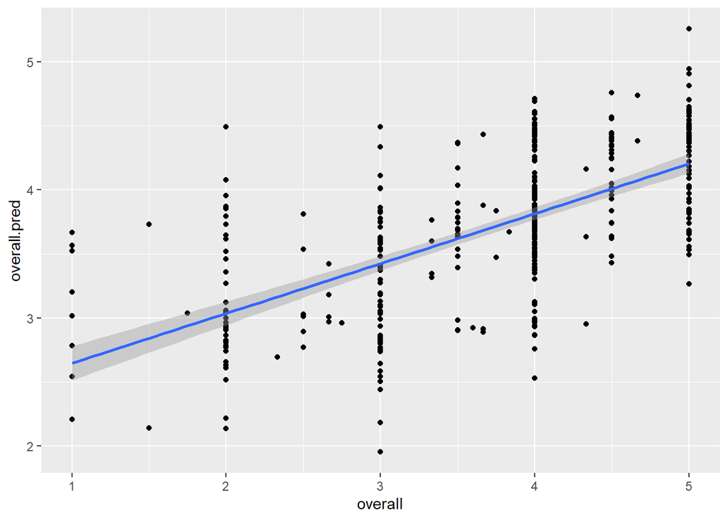

```r
prelockdown.data$overall.pred <- predict(selected.mod, newdata = prelockdown.data)
ggplot(prelockdown.data, aes(x=overall, y=overall.pred)) + geom_point() +
    geom_smooth(method=lm)
```

```r
cor(prelockdown.data$overall, prelockdown.data$overall.pred)
```

```
## [1] 0.6357836
```

```r
cor(prelockdown.data$overall, prelockdown.data$overall.pred)^2
```

```
## [1] 0.4042207
```

```r
var(prelockdown.data$overall, prelockdown.data$overall.pred)
```

```
## [1] 0.3840967
```

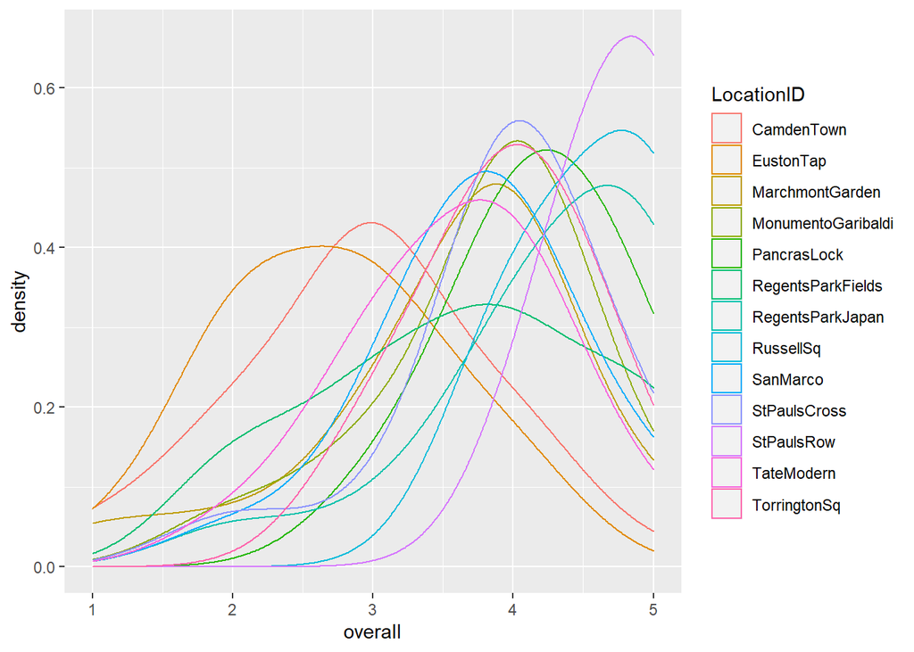

```r
ggplot(prelockdown.data, aes(x = overall, color=LocationID)) +
    geom_density(bw=.5)
```

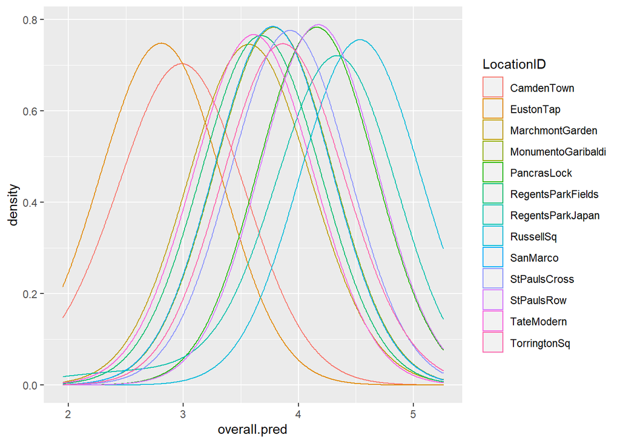

```r
ggplot(prelockdown.data, aes(x = overall.pred, color=LocationID)) +
    geom_density(bw=.5)
```

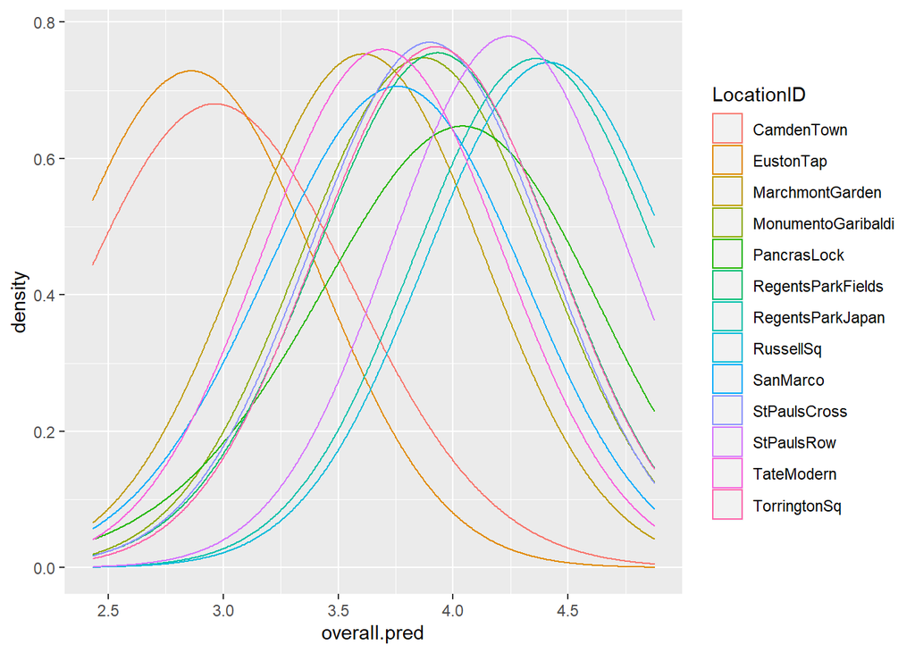

```r
lockdown.data$overall.pred <- predict(selected.mod, newdata = lockdown.data)
ggplot(lockdown.data, aes(x = overall.pred, color=LocationID)) +
    geom_density(bw=.5)
```

# Model for `Natural`

### Filtering features

```r
all_features <- list(FS_stats, FS_variation, LAeq_stats, LAeq_variation, LCeq_stats, LCeq_variation, LZeq_stats, LZeq_variation, N_stats, N_variation, R_stats, R_variation, S_stats, S_variation, SIL_stats, SIL_variation, T_stats, T_variation, I_stats, I_variation, THD_stats, THD_variation, frequency_features)

for(item in all_features) {
    results <- max_corr(item, "Natural", prelockdown.data)
    print(results)
}
```

```
## [1] "FS_95"              "-0.134597538016657"
## [1] "FS_Max.FS_Min"      "-0.084949932422842"
## [1] "LAeq_Max"           "-0.428833816590953"
## [1] "LAeq_5.LAeq_95"     "-0.335918803190455"
## [1] "LCeq_5"             "-0.525030581162201"
## [1] "LCeq_5.LCeq_95"     "-0.327898862618056"
## [1] "LZeq_10"            "-0.511064617213779"
## [1] "LZeq_5.LZeq_95"     "-0.244277106746308"
## [1] "N_Max"              "-0.415884197870181"
## [1] "N_5.N_95"          "-0.45742082866304"
## [1] "R_95"               "-0.513270003469495"
## [1] "R_5.R_95"           "-0.227751044534389"
## [1] "S_Min"             "0.241960491458002"
## [1] "S_5.S_95"           "-0.333173250883801"
## [1] "SIL_Max"            "-0.420299230018646"
## [1] "SIL_5.SIL_95"       "-0.386930685465244"
## [1] "T_Max"              "-0.289651044889494"
## [1] "T_10.T_90"          "-0.262967999137697"
## [1] "I_95"                "-0.0909259722839188"
## [1] "I_5.I_95"            "-0.0500973124825619"
## [1] "THD_Min"           "0.130961786571236"
## [1] "THD_5.THD_95"      "-0.18339957377495"
## [1] "SpectralCentroid"  "0.140652232705908"
```

So our new, filtered feature set will be:

```r
Natural.features <- c("FS_95", "FS_Max.FS_Min", "LAeq_Max", "LAeq_5.LAeq_95", "LCeq_5", "LCeq_10.LCeq_90", "LZeq_5", "LZeq_5.LZeq_95", "N_Max", "N_5.N_95", "R_95", "R_5.R_95", "S_Min", "S_Max.S_Min", "SIL_Max", "SIL_5.SIL_95", "T_50", "T_10.T_90", "I_95", "I_5.I_95", "THD_Max", "THD_5.THD_95", "SpectralCentroid")

mlm.Natural <- lmer(Natural ~ FS_95 + FS_Max.FS_Min + LAeq_Max + LAeq_5.LAeq_95 + LCeq_5 + LCeq_10.LCeq_90 + LZeq_5 + LZeq_5.LZeq_95 + N_Max + N_5.N_95 + R_95 + R_5.R_95 + S_Min + S_Max.S_Min + SIL_Max + SIL_5.SIL_95 + T_50 + T_10.T_90 + I_95 + I_5.I_95 + THD_Max + THD_5.THD_95 + SpectralCentroid + MaxFreq + PeakSpectralCentroid + PeakMaxFreq + (1|LocationID), data = prelockdown.data)

stepMod <- lmerTest::step(mlm.Natural)
stepMod
```

```
## Backward reduced random-effect table:
##
##                  Eliminated npar  logLik    AIC    LRT Df Pr(>Chisq)
## <none>                        29 -542.46 1142.9
## (1 | LocationID)          0   28 -545.00 1146.0 5.0889  1    0.02408 *
## ---
## Signif. codes:  0 '***' 0.001 '**' 0.01 '*' 0.05 '.' 0.1 ' ' 1
##
## Backward reduced fixed-effect table:
## Degrees of freedom method: Satterthwaite
##
##                      Eliminated  Sum Sq Mean Sq NumDF  DenDF F value    Pr(>F)
## LAeq_Max                      1  0.0014  0.0014     1 367.06  0.0019   0.96555
## I_95                          2  0.0041  0.0041     1 365.27  0.0056   0.94013
## LZeq_5                        3  0.0056  0.0056     1 346.51  0.0076   0.93062
## R_5.R_95                      4  0.0055  0.0055     1 369.52  0.0075   0.93086
## LAeq_5.LAeq_95                5  0.0103  0.0103     1 377.13  0.0142   0.90522
## S_Max.S_Min                   6  0.0148  0.0148     1 375.02  0.0203   0.88667
## SIL_Max                       7  0.0365  0.0365     1 378.68  0.0504   0.82242
## MaxFreq                       8  0.0620  0.0620     1 360.20  0.0857   0.76983
## THD_5.THD_95                  9  0.0658  0.0658     1 349.42  0.0913   0.76268
## FS_95                        10  0.1013  0.1013     1 381.73  0.1408   0.70766
## T_50                         11  0.1500  0.1500     1 379.66  0.2092   0.64766
## N_5.N_95                     12  0.1590  0.1590     1 384.09  0.2219   0.63783
## N_Max                        13  0.1799  0.1799     1 384.72  0.2516   0.61623
## SpectralCentroid             14  0.4634  0.4634     1 334.97  0.6490   0.42104
## FS_Max.FS_Min                15  0.5860  0.5860     1 384.26  0.8220   0.36515
## LZeq_5.LZeq_95               16  0.8131  0.8131     1 340.60  1.1419   0.28600
## LCeq_10.LCeq_90              17  0.9126  0.9126     1 214.40  1.2780   0.25953
## PeakSpectralCentroid         18  1.0745  1.0745     1 351.38  1.5110   0.21980
## I_5.I_95                     19  0.5240  0.5240     1 391.29  0.7394   0.39039
## SIL_5.SIL_95                 20  2.0655  2.0655     1 378.46  2.9244   0.08807
## THD_Max                      21  2.1581  2.1581     1 371.88  3.0395   0.08209
## R_95                         22  1.3386  1.3386     1 241.11  1.8751   0.17216
## LCeq_5                        0 26.4930 26.4930     1 205.94 37.2395 5.106e-09
## S_Min                         0 14.5617 14.5617     1 168.57 20.4685 1.140e-05
## T_10.T_90                     0  4.1480  4.1480     1 390.03  5.8306   0.01621
## PeakMaxFreq                   0  4.2361  4.2361     1 391.18  5.9544   0.01512
##
## LAeq_Max
```

[output cut: 15 more lines]

```
## LCeq_10.LCeq_90
## PeakSpectralCentroid
## I_5.I_95
## SIL_5.SIL_95         .
## THD_Max              .
## R_95
## LCeq_5               ***
## S_Min                ***
## T_10.T_90            *
## PeakMaxFreq          *
## ---
## Signif. codes:  0 '***' 0.001 '**' 0.01 '*' 0.05 '.' 0.1 ' ' 1
##
## Model found:
## Natural ~ LCeq_5 + S_Min + T_10.T_90 + PeakMaxFreq + (1 | LocationID)
```

```r
selected.mod <- get_model(stepMod)
summary(selected.mod)
```

```
## Linear mixed model fit by REML. t-tests use Satterthwaite's method [
## lmerModLmerTest]
## Formula: Natural ~ LCeq_5 + S_Min + T_10.T_90 + PeakMaxFreq + (1 | LocationID)
##    Data: prelockdown.data
##
## REML criterion at convergence: 1038.6
##
## Scaled residuals:
##     Min      1Q  Median      3Q     Max
## -3.5844 -0.6727 -0.0698  0.6445  2.8395
##
## Random effects:
##  Groups     Name        Variance Std.Dev.
##  LocationID (Intercept) 0.1450   0.3808
##  Residual               0.7114   0.8435
## Number of obs: 401, groups:  LocationID, 13
##
## Fixed effects:
##              Estimate Std. Error        df t value Pr(>|t|)
## (Intercept)   2.55646    0.12025  10.05921  21.260 1.08e-09 ***
## LCeq_5       -0.45106    0.07391 205.93700  -6.102 5.11e-09 ***
## S_Min         0.30114    0.06656 168.57095   4.524 1.14e-05 ***
## T_10.T_90     0.11209    0.04642 390.03088   2.415   0.0162 *
## PeakMaxFreq  -0.11105    0.04551 391.18229  -2.440   0.0151 *
## ---
## Signif. codes:  0 '***' 0.001 '**' 0.01 '*' 0.05 '.' 0.1 ' ' 1
##
## Correlation of Fixed Effects:
##             (Intr) LCeq_5 S_Min  T_10.T
## LCeq_5       0.030
## S_Min       -0.152 -0.418
## T_10.T_90   -0.092 -0.469  0.231
## PeakMaxFreq -0.025  0.158 -0.123 -0.273
```

```r
r.squaredGLMM(selected.mod)
```

```
##            R2m       R2c
## [1,] 0.1971102 0.3330463
```

```r
vif(selected.mod, data = prelockdown.data)
```

```
##      LCeq_5       S_Min   T_10.T_90 PeakMaxFreq
##    1.473564    1.218250    1.352915    1.085078
```

## Checking prediction behaviour

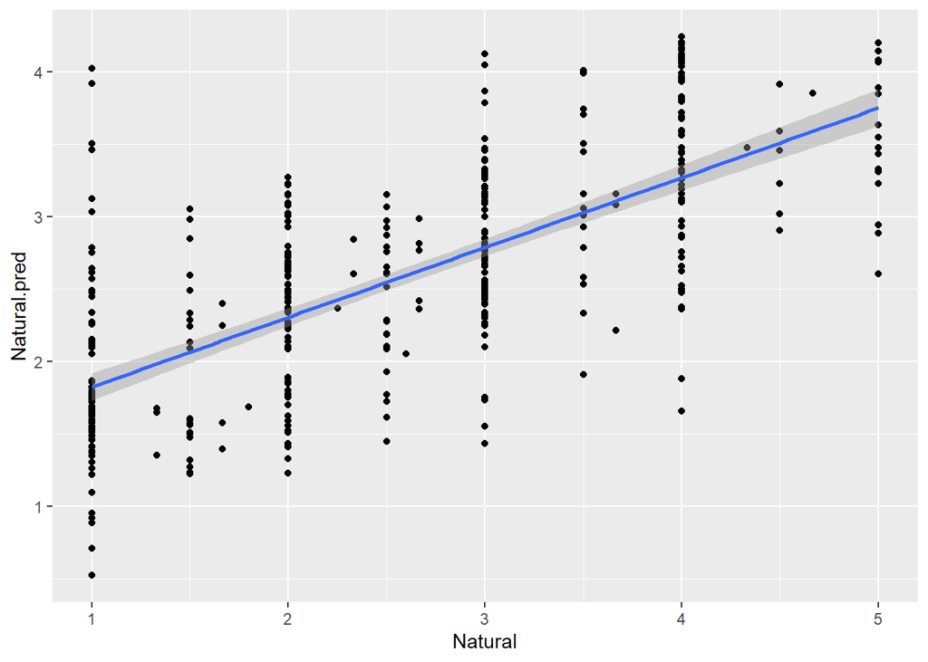

```r
prelockdown.data$Natural.pred <- predict(selected.mod, newdata = prelockdown.data)
ggplot(prelockdown.data, aes(x=Natural, y=Natural.pred)) + geom_point() +
    geom_smooth(method=lm)
```

```r
cor(prelockdown.data$Natural, prelockdown.data$Natural.pred)
```

```
## [1] 0.7030939
```

```r
cor(prelockdown.data$Natural, prelockdown.data$Natural.pred)^2
```

```
## [1] 0.4943411
```

```r
var(prelockdown.data$Natural, prelockdown.data$Natural.pred)
```

```
## [1] 0.6552219
```

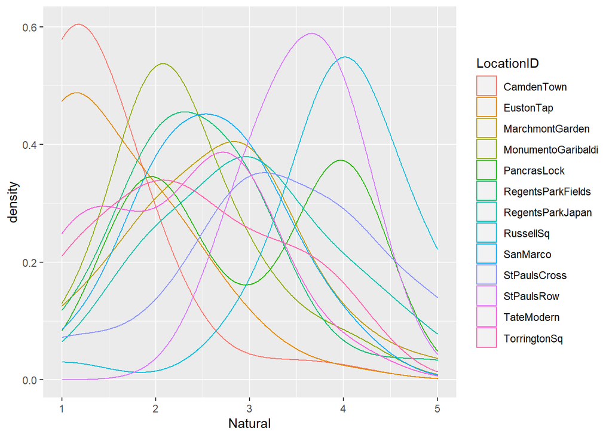

```r
ggplot(prelockdown.data, aes(x = Natural, color=LocationID)) +
    geom_density(bw=.5)
```

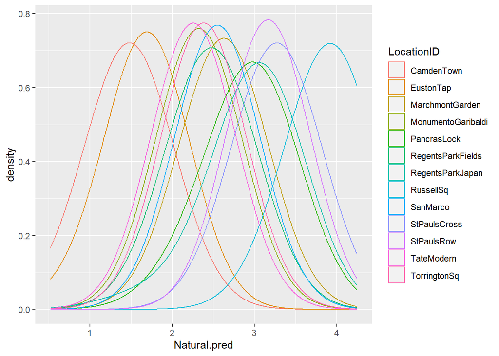

```r
ggplot(prelockdown.data, aes(x = Natural.pred, color=LocationID)) +
    geom_density(bw=.5)
```

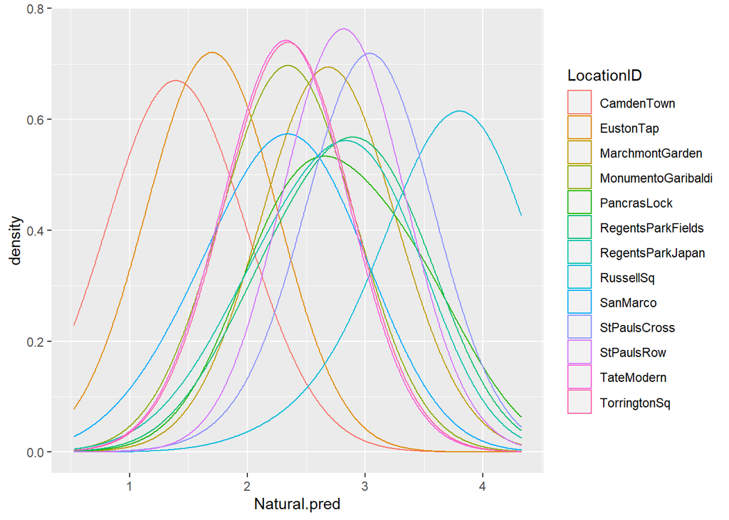

```r
lockdown.data$Natural.pred <- predict(selected.mod, newdata = lockdown.data)
ggplot(lockdown.data, aes(x = Natural.pred, color=LocationID)) +
    geom_density(bw=.5)
```

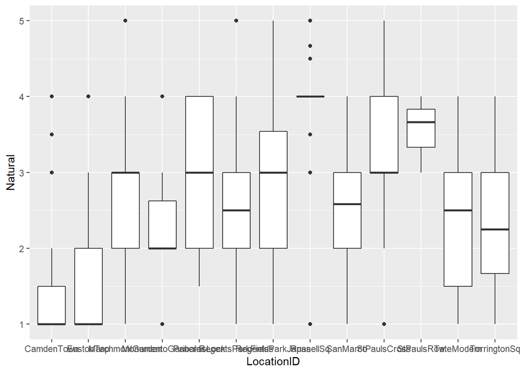

```r
ggplot(prelockdown.data, aes(x=LocationID, y=Natural)) +
    geom_boxplot()
```

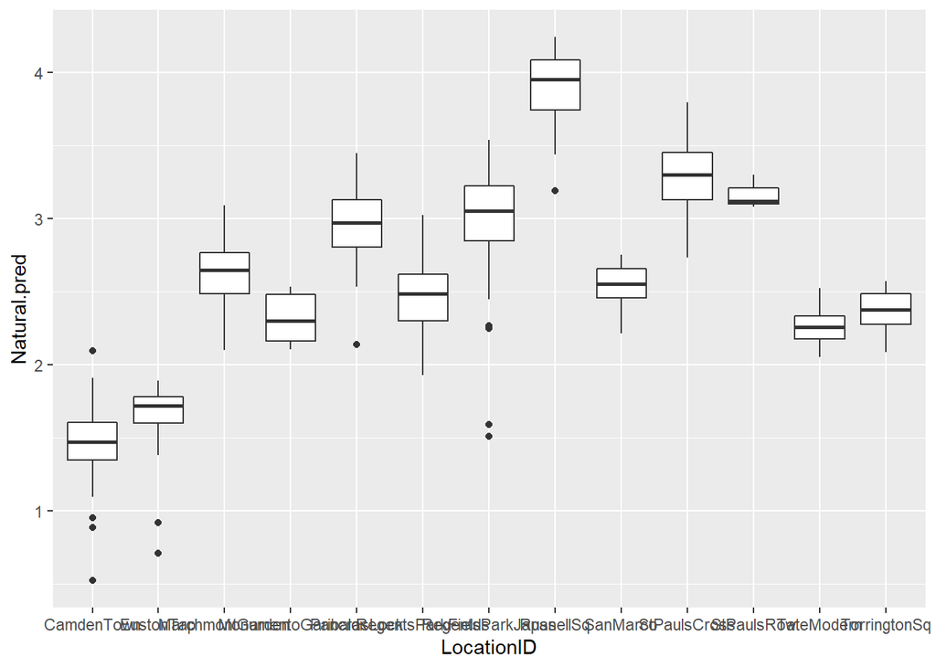

```r
ggplot(prelockdown.data, aes(x=LocationID, y=Natural.pred)) +
    geom_boxplot()
```

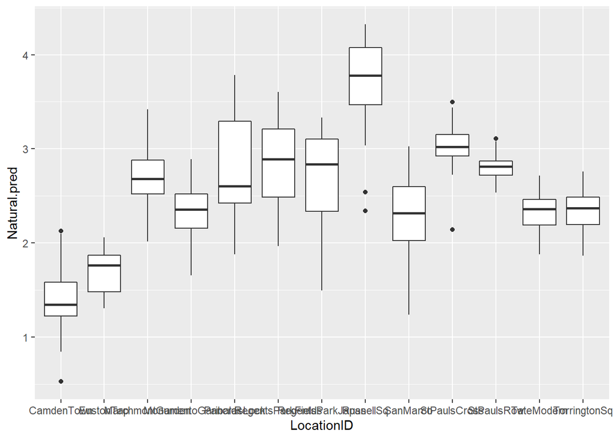

```r
ggplot(lockdown.data, aes(x=LocationID, y=Natural.pred)) +
    geom_boxplot()
```

# Model for `Pleasant`

### Filtering features

```r
all_features <- list(FS_stats, FS_variation, LAeq_stats, LAeq_variation, LCeq_stats, LCeq_variation, LZeq_stats, LZeq_variation, N_stats, N_variation, R_stats, R_variation, S_stats, S_variation, SIL_stats, SIL_variation, T_stats, T_variation, I_stats, I_variation, THD_stats, THD_variation, frequency_features)

for(item in all_features) {
    results <- max_corr(item, "Pleasant", prelockdown.data)
    print(results)
}
```

```
## [1] "FS_95"               "-0.0832178785375554"
## [1] "FS_10.FS_90"        "0.0551127327057273"
## [1] "LAeq_5"             "-0.426774769997692"
## [1] "LAeq_10.LAeq_90"    "-0.213518639839596"
## [1] "LCeq_10"            "-0.505444943994987"
## [1] "LCeq_10.LCeq_90"    "-0.242056481640611"
## [1] "LZeq_50"            "-0.481689545317984"
## [1] "LZeq_10.LZeq_90"    "-0.154520431469205"
## [1] "N_10"             "-0.4313253412439"
## [1] "N_10.N_90"          "-0.406952035932633"
## [1] "R_95"               "-0.497396101544108"
## [1] "R_10.R_90"          "-0.176459122699419"
## [1] "S_Max"              "-0.186252142720628"
## [1] "S_10.S_90"          "-0.238136116500487"
## [1] "SIL_Max"           "-0.43066777585075"
## [1] "SIL_10.SIL_90"      "-0.256805198576302"
## [1] "T_10"               "-0.238105363312161"
## [1] "T_10.T_90"          "-0.232886554769225"
## [1] "I_Max"              "0.0687734971812469"
## [1] "I_Max.I_Min"        "0.0677845694351673"
## [1] "THD_Min"            "0.0998328016268762"
## [1] "THD_5.THD_95"       "-0.156862657128557"
## [1] "MaxFreq"            "0.0893116434585522"
```

So our new, filtered feature set will be:

```r
Pleasant.features <- c("FS_95", "FS_Max.FS_Min", "LAeq_Max", "LAeq_5.LAeq_95", "LCeq_5", "LCeq_10.LCeq_90", "LZeq_5", "LZeq_5.LZeq_95", "N_Max", "N_5.N_95", "R_95", "R_5.R_95", "S_Min", "S_Max.S_Min", "SIL_Max", "SIL_5.SIL_95", "T_50", "T_10.T_90", "I_95", "I_5.I_95", "THD_Max", "THD_5.THD_95", "SpectralCentroid")

mlm.Pleasant <- lmer(Pleasant ~ FS_95 + FS_Max.FS_Min + LAeq_Max + LAeq_5.LAeq_95 + LCeq_5 + LCeq_10.LCeq_90 + LZeq_5 + LZeq_5.LZeq_95 + N_Max + N_5.N_95 + R_95 + R_5.R_95 + S_Min + S_Max.S_Min + SIL_Max + SIL_5.SIL_95 + T_50 + T_10.T_90 + I_95 + I_5.I_95 + THD_Max + THD_5.THD_95 + SpectralCentroid + MaxFreq + PeakSpectralCentroid + PeakMaxFreq + (1|LocationID), data = prelockdown.data)

stepMod <- lmerTest::step(mlm.Pleasant)
stepMod
```

```
## Backward reduced random-effect table:
##
##                  Eliminated npar  logLik    AIC    LRT Df Pr(>Chisq)
## <none>                        29 -168.73 395.47
## (1 | LocationID)          0   28 -178.64 413.28 19.815  1   8.53e-06 ***
## ---
## Signif. codes:  0 '***' 0.001 '**' 0.01 '*' 0.05 '.' 0.1 ' ' 1
##
## Backward reduced fixed-effect table:
## Degrees of freedom method: Satterthwaite
##
##                      Eliminated  Sum Sq Mean Sq NumDF  DenDF F value    Pr(>F)
## I_5.I_95                      1 0.00008 0.00008     1 373.94  0.0008  0.976860
## LAeq_Max                      2 0.00051 0.00051     1 368.52  0.0052  0.942621
## SIL_5.SIL_95                  3 0.00314 0.00314     1 375.93  0.0320  0.858058
## LAeq_5.LAeq_95                4 0.00218 0.00218     1 373.39  0.0223  0.881454
## S_Max.S_Min                   5 0.00267 0.00267     1 377.89  0.0274  0.868620
## S_Min                         6 0.00370 0.00370     1 290.50  0.0380  0.845598
## PeakMaxFreq                   7 0.00538 0.00538     1 372.48  0.0555  0.813967
## T_50                          8 0.00802 0.00802     1 379.44  0.0828  0.773665
## N_Max                         9 0.01157 0.01157     1 381.97  0.1199  0.729323
## LZeq_5                       10 0.01207 0.01207     1 365.18  0.1254  0.723485
## LCeq_5                       11 0.00330 0.00330     1 233.78  0.0344  0.853099
## LCeq_10.LCeq_90              12 0.00807 0.00807     1 384.73  0.0842  0.771819
## THD_5.THD_95                 13 0.02051 0.02051     1 385.98  0.2146  0.643485
## FS_95                        14 0.02812 0.02812     1 384.13  0.2945  0.587687
## T_10.T_90                    15 0.04165 0.04165     1 385.40  0.4366  0.509140
## R_5.R_95                     16 0.05465 0.05465     1 387.32  0.5743  0.449024
## N_5.N_95                     17 0.07685 0.07685     1 389.64  0.8091  0.368938
## SpectralCentroid             18 0.13055 0.13055     1 254.49  1.3766  0.241784
## PeakSpectralCentroid         19 0.21033 0.21033     1 390.70  2.2256  0.136543
## LZeq_5.LZeq_95               20 0.13419 0.13419     1 393.00  1.4179  0.234470
## I_95                         21 0.20874 0.20874     1 380.38  2.2056  0.138335
## R_95                         22 0.27984 0.27984     1 361.95  2.9458  0.086956
## THD_Max                      23 0.25598 0.25598     1 392.18  2.6962  0.101389
## FS_Max.FS_Min                 0 0.67927 0.67927     1 393.92  7.1189  0.007943
## SIL_Max                       0 2.93417 2.93417     1 328.16 30.7506 6.043e-08
## MaxFreq                       0 0.58138 0.58138     1 395.46  6.0930  0.013994
##
## I_5.I_95
```

[output cut: 15 more lines]

```
## N_5.N_95
## SpectralCentroid
## PeakSpectralCentroid
## LZeq_5.LZeq_95
## I_95
## R_95                 .
## THD_Max
## FS_Max.FS_Min        **
## SIL_Max              ***
## MaxFreq              *
## ---
## Signif. codes:  0 '***' 0.001 '**' 0.01 '*' 0.05 '.' 0.1 ' ' 1
##
## Model found:
## Pleasant ~ FS_Max.FS_Min + SIL_Max + MaxFreq + (1 | LocationID)
```

```r
selected.mod <- get_model(stepMod)
summary(selected.mod)
```

```
## Linear mixed model fit by REML. t-tests use Satterthwaite's method [
## lmerModLmerTest]
## Formula: Pleasant ~ FS_Max.FS_Min + SIL_Max + MaxFreq + (1 | LocationID)
##    Data: prelockdown.data
##
## REML criterion at convergence: 242.6
##
## Scaled residuals:
##     Min      1Q  Median      3Q     Max
## -4.8637 -0.5526  0.0888  0.6203  2.2079
##
## Random effects:
##  Groups     Name        Variance Std.Dev.
##  LocationID (Intercept) 0.02971  0.1724
##  Residual               0.09542  0.3089
## Number of obs: 401, groups:  LocationID, 13
##
## Fixed effects:
##                Estimate Std. Error        df t value Pr(>|t|)
## (Intercept)     0.34711    0.05280  13.22540   6.574 1.64e-05 ***
## FS_Max.FS_Min   0.03539    0.01326 393.92159   2.668  0.00794 **
## SIL_Max        -0.15143    0.02731 328.16203  -5.545 6.04e-08 ***
## MaxFreq         0.04757    0.01927 395.45945   2.468  0.01399 *
## ---
## Signif. codes:  0 '***' 0.001 '**' 0.01 '*' 0.05 '.' 0.1 ' ' 1
##
## Correlation of Fixed Effects:
##             (Intr) FS_M.F SIL_Mx
## FS_Mx.FS_Mn  0.002
## SIL_Max     -0.185 -0.299
## MaxFreq      0.058 -0.053 -0.399
```

```r
r.squaredGLMM(selected.mod)
```

```
##            R2m       R2c
## [1,] 0.1229941 0.3312037
```

```r
library(car)
vif(selected.mod, data = prelockdown.data)
```

```
## FS_Max.FS_Min       SIL_Max       MaxFreq
##      1.142264      1.354327      1.236758
```

## Checking prediction behaviour

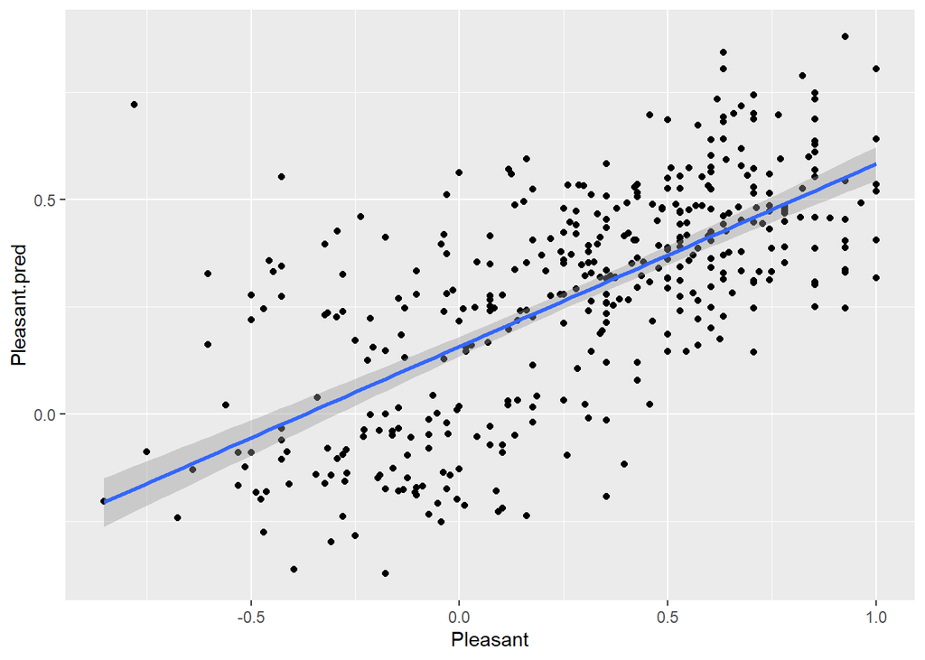

```r
prelockdown.data$Pleasant.pred <- predict(selected.mod, newdata = prelockdown.data)
ggplot(prelockdown.data, aes(x=Pleasant, y=Pleasant.pred)) + geom_point() +
    geom_smooth(method=lm)
```

```r
cor(prelockdown.data$Pleasant, prelockdown.data$Pleasant.pred)
```

```
## [1] 0.6640517
```

```r
cor(prelockdown.data$Pleasant, prelockdown.data$Pleasant.pred)^2
```

```
## [1] 0.4409647
```

```r
var(prelockdown.data$Pleasant, prelockdown.data$Pleasant.pred)
```

```
## [1] 0.07024568
```

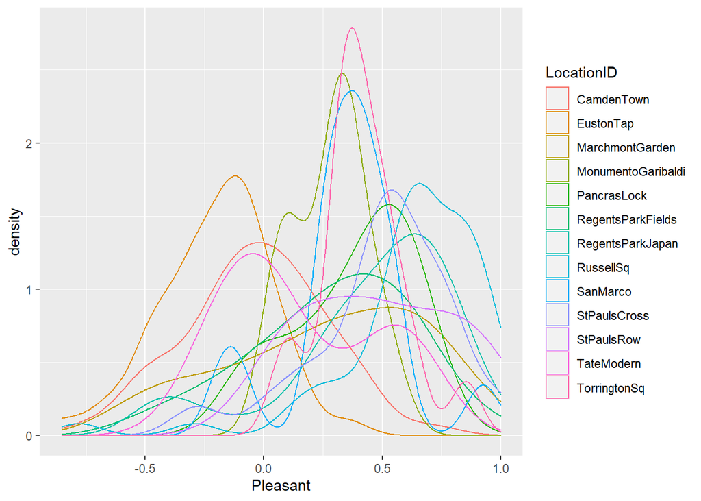

```r
ggplot(prelockdown.data, aes(x = Pleasant, color=LocationID)) +
    geom_density()
```

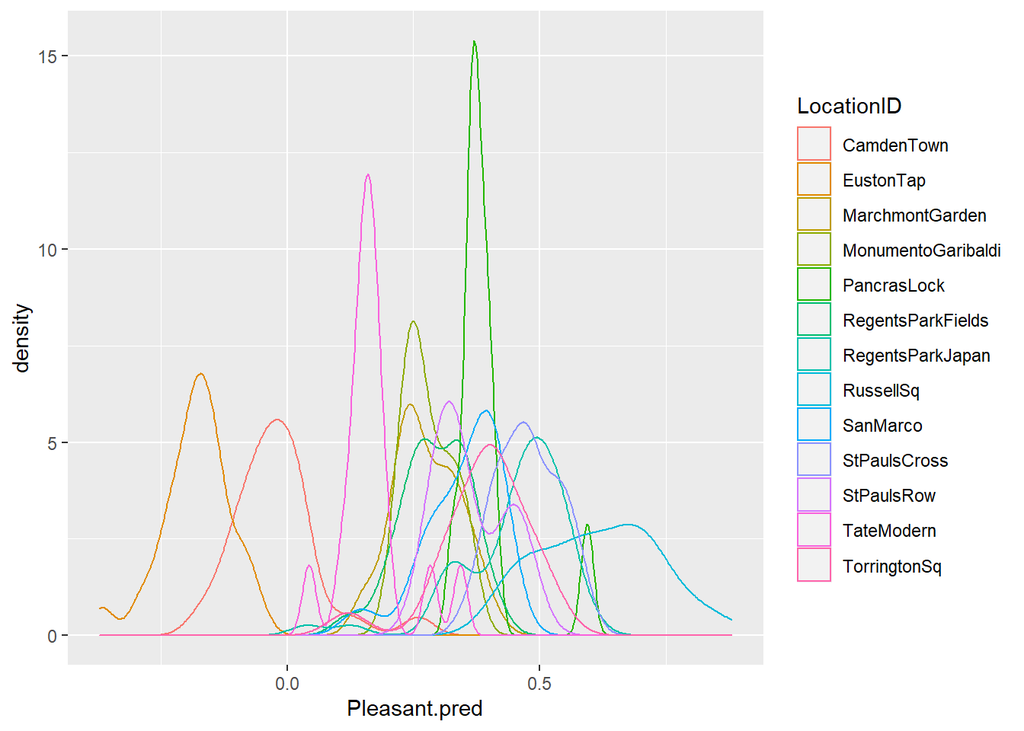

```r
ggplot(prelockdown.data, aes(x = Pleasant.pred, color=LocationID)) +
    geom_density()
```

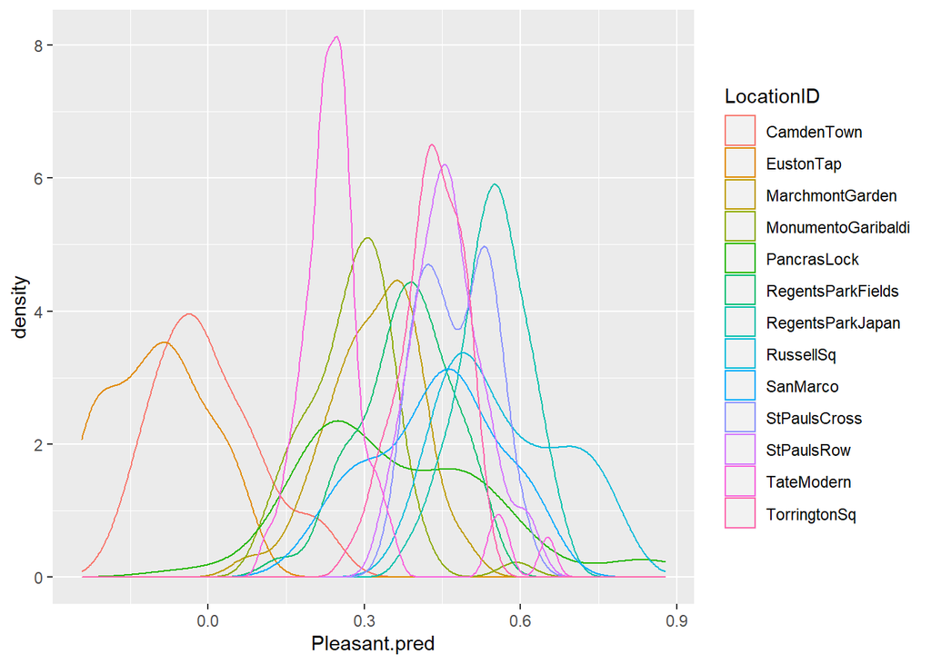

```r
lockdown.data$Pleasant.pred <- predict(selected.mod, newdata = lockdown.data)
ggplot(lockdown.data, aes(x = Pleasant.pred, color=LocationID)) +
    geom_density()
```

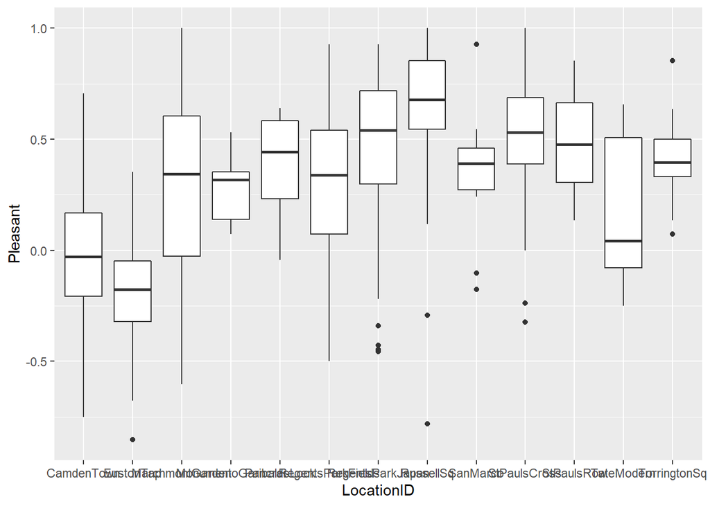

```r
ggplot(prelockdown.data, aes(x=LocationID, y=Pleasant)) +
    geom_boxplot()
```

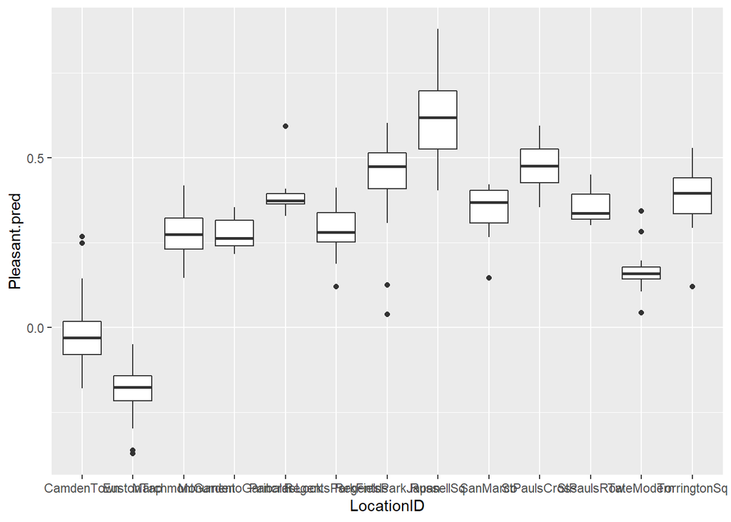

```r
ggplot(prelockdown.data, aes(x=LocationID, y=Pleasant.pred)) +
    geom_boxplot()
```

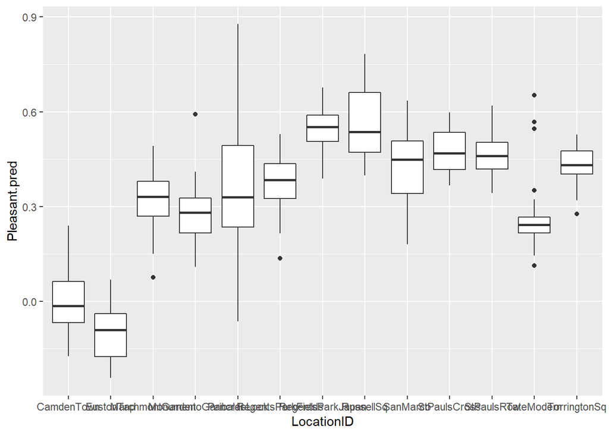

```r
ggplot(lockdown.data, aes(x=LocationID, y=Pleasant.pred)) +
    geom_boxplot()
```